# Aerofit_Project

**Aerofit** is one of the leading fitness equipment brands in India. Aerofit provides a product range including machines such as treadmills, exercise bikes, gym equipment, and fitness accessories to cater to the needs of all categories of people. It was founded in 1928.

As of today, they have multiple retail stores spread throughout the country.

- **The objective of this project is to provide information to the sales team that can help them to profile the customer more accurately and help them to identify a potential customer easily.**
- **This analysis will also help to increase overall sales by targeting the right customer with the right product.**

This research is more focused on the below three treadmill models introduced by Aerofit in the market.

- **The KP281 is an entry-level treadmill that sells for $1,500.**
- **The KP481 is for mid-level runners that sell for $1,750.**
- **The KP781 treadmill is having advanced features that sell for $2,500.**

# ***1. Dataset***

```python
import numpy as np
import pandas as pd
import matplotlib.pyplot as plt
import seaborn as sns
```

```python
df = pd.read_csv("Aerofit_Data.csv")
```

#### ***How the data looks.***

```python
df.head(10)
```

|  | Product | Age | Gender | Education | MaritalStatus | Usage | Fitness | Income | Miles |
| --- | --- | --- | --- | --- | --- | --- | --- | --- | --- |
| 0 | KP281 | 18 | Male | 14 | Single | 3 | 4 | 29562 | 112 |
| 1 | KP281 | 19 | Male | 15 | Single | 2 | 3 | 31836 | 75 |
| 2 | KP281 | 19 | Female | 14 | Partnered | 4 | 3 | 30699 | 66 |
| 3 | KP281 | 19 | Male | 12 | Single | 3 | 3 | 32973 | 85 |
| 4 | KP281 | 20 | Male | 13 | Partnered | 4 | 2 | 35247 | 47 |
| 5 | KP281 | 20 | Female | 14 | Partnered | 3 | 3 | 32973 | 66 |
| 6 | KP281 | 21 | Female | 14 | Partnered | 3 | 3 | 35247 | 75 |
| 7 | KP281 | 21 | Male | 13 | Single | 3 | 3 | 32973 | 85 |
| 8 | KP281 | 21 | Male | 15 | Single | 5 | 4 | 35247 | 141 |
| 9 | KP281 | 21 | Female | 15 | Partnered | 2 | 3 | 37521 | 85 |

#### ***Column Discriptions***

1. **Product Purchased:** KP281, KP481, or KP781.
2. **Age:** In years
3. **Gender:** Male/Female
4. **Education:** In years
5. **MaritalStatus:** Single or partnered
6. **Usage:** The average number of times the customer plans to use the treadmill each week.
7. **Income:** Annual income (in $)
8. **Fitness:** Self-rated fitness on a 1-to-5 scale, where 1 is the poor shape and 5 is the excellent shape.
9. **Miles:** The average number of miles the customer expects to walk/run each week

```python
df.dtypes
```

```
Product          object
Age               int64
Gender           object
Education         int64
MaritalStatus    object
Usage             int64
Fitness           int64
Income            int64
Miles             int64
dtype: object
```

#### ***We have a data of 180 samples***

```python
df.shape
```

```
(180, 9)
```

# ***2. Missing Data Analysis***

#### ***There are no missing data***

```python
df.isnull().sum(axis=0)
```

```
Product          0
Age              0
Gender           0
Education        0
MaritalStatus    0
Usage            0
Fitness          0
Income           0
Miles            0
dtype: int64
```

# ***3. Verifying the values in the each columns.***

```python
df.agg([min,max])
```

|  | Product | Age | Gender | Education | MaritalStatus | Usage | Fitness | Income | Miles |
| --- | --- | --- | --- | --- | --- | --- | --- | --- | --- |
| min | KP281 | 18 | Female | 12 | Partnered | 2 | 1 | 29562 | 21 |
| max | KP781 | 50 | Male | 21 | Single | 7 | 5 | 104581 | 360 |

***The "Miles" have an unrealistic value of 360. Lets check all the values of this column.***

```python
df.describe(include = 'all')
```

|  | Product | Age | Gender | Education | MaritalStatus | Usage | Fitness | Income | Miles |
| --- | --- | --- | --- | --- | --- | --- | --- | --- | --- |
| count | 180 | 180.000000 | 180 | 180.000000 | 180 | 180.000000 | 180.000000 | 180.000000 | 180.000000 |
| unique | 3 | NaN | 2 | NaN | 2 | NaN | NaN | NaN | NaN |
| top | KP281 | NaN | Male | NaN | Partnered | NaN | NaN | NaN | NaN |
| freq | 80 | NaN | 104 | NaN | 107 | NaN | NaN | NaN | NaN |
| mean | NaN | 28.788889 | NaN | 15.572222 | NaN | 3.455556 | 3.311111 | 53719.577778 | 103.194444 |
| std | NaN | 6.943498 | NaN | 1.617055 | NaN | 1.084797 | 0.958869 | 16506.684226 | 51.863605 |
| min | NaN | 18.000000 | NaN | 12.000000 | NaN | 2.000000 | 1.000000 | 29562.000000 | 21.000000 |
| 25% | NaN | 24.000000 | NaN | 14.000000 | NaN | 3.000000 | 3.000000 | 44058.750000 | 66.000000 |
| 50% | NaN | 26.000000 | NaN | 16.000000 | NaN | 3.000000 | 3.000000 | 50596.500000 | 94.000000 |
| 75% | NaN | 33.000000 | NaN | 16.000000 | NaN | 4.000000 | 4.000000 | 58668.000000 | 114.750000 |
| max | NaN | 50.000000 | NaN | 21.000000 | NaN | 7.000000 | 5.000000 | 104581.000000 | 360.000000 |

#### ***From the above table we can find the** Median** values***

1. **median(Age)** : 26
2. **median(Education)** : 16
3. **median(Fitness)** : 3
4. **median(Income)** : 50596
5. **median(Miles)** : 94

#### *****Miles**,**Income** columns have most number of outliers***

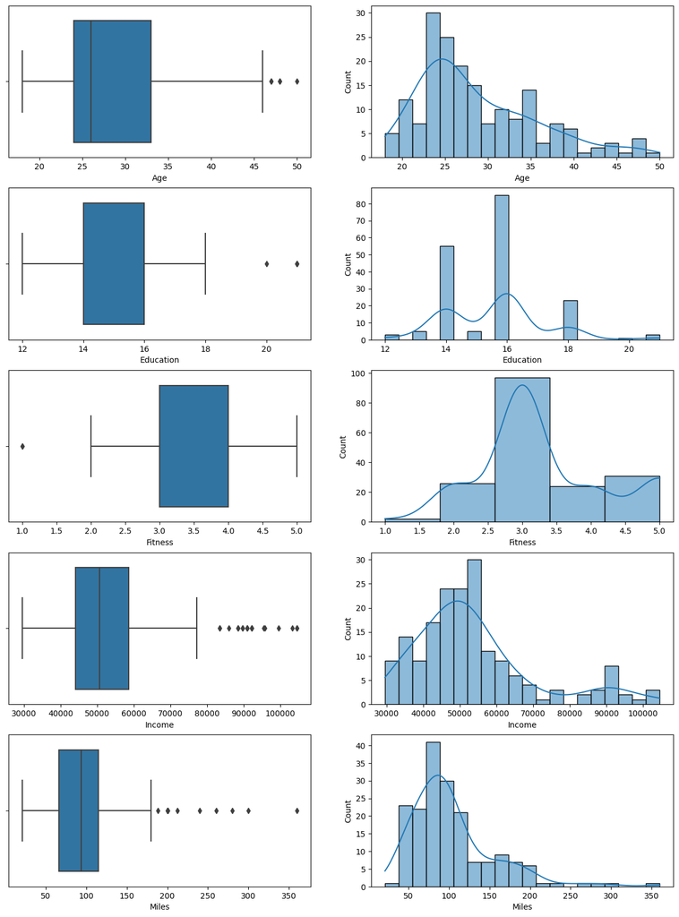

```python
fig = plt.figure(figsize=(15,20))

plt.subplot(5,2,1)
sns.boxplot(df,x = "Age")

plt.subplot(5,2,2)
sns.histplot(data = df,x = "Age", kde = True, bins= 20)

plt.subplot(5,2,3)
sns.boxplot(df,x = "Education")

plt.subplot(5,2,4)
sns.histplot(data = df,x = "Education", kde = True, bins= 20)

plt.subplot(5,2,5)
sns.boxplot(df,x = "Fitness")

plt.subplot(5,2,6)
sns.histplot(data = df,x = "Fitness", kde = True, bins= 5)

plt.subplot(5,2,7)
sns.boxplot(df,x = "Income")

plt.subplot(5,2,8)
sns.histplot(data = df,x = "Income", kde = True, bins= 20)

plt.subplot(5,2,9)
sns.boxplot(df,x = "Miles")

plt.subplot(5,2,10)
sns.histplot(data = df,x = "Miles", kde = True, bins= 20)

plt.show()
```

***The data here is highly skewed due to the presence of the outliers.***

# ***4. Univariate Analysis***

```
[Text(0, 0, '80'), Text(0, 0, '60'), Text(0, 0, '40')]
```

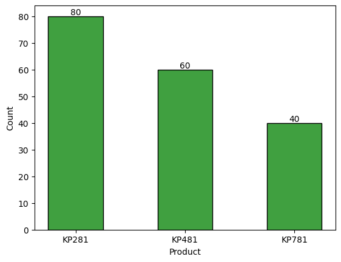

```python
y = sns.histplot(data = df, x = "Product", shrink = 0.5, color = "Green")
y.bar_label(y.containers[0])
```

### ***Insights***

1. From the above graph its evident that **KP281** is highest selling product out of the three product.

followed by **KP481** and **KP781**

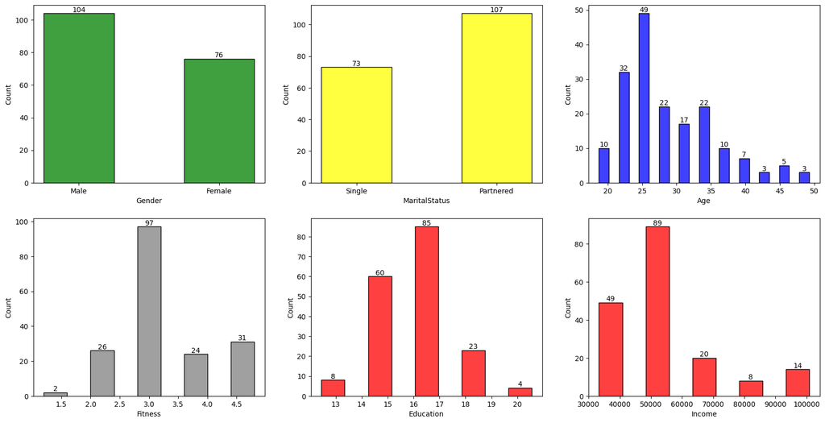

```python
fig = plt.figure(figsize=(20,10))

plt.subplot(2,3,1)
y = sns.histplot(data = df, x = "Gender", shrink = 0.5, color = "Green")
y.bar_label(y.containers[0])

plt.subplot(2,3,2)
y = sns.histplot(data = df, x = "MaritalStatus", shrink = 0.5, color = "yellow")
y.bar_label(y.containers[0])

plt.subplot(2,3,3)
y = sns.histplot(data = df, x = "Age", shrink = 0.5, color = "Blue")
y.bar_label(y.containers[0])

plt.subplot(2,3,4)
y = sns.histplot(data = df, x = "Fitness", shrink = 0.5, color = "Grey",bins=5)
y.bar_label(y.containers[0])

plt.subplot(2,3,5)
y = sns.histplot(data = df, x = "Education", shrink = 0.5, color = "Red",bins=5)
y.bar_label(y.containers[0])

plt.subplot(2,3,6)
y = sns.histplot(data = df, x = "Income", shrink = 0.5, color = "Red",bins=5)
y.bar_label(y.containers[0])

plt.show()
```

### ***Insights:***

1. Male customer purchase more.
2. Partnered customer purchase more.
3. Customer age betwwen 21 and 35 purchase more.
4. Customer with 3.0 fitness rating purchase more.
5. customer with education between 14 and 17 purchase more.
6. Customer with salary betwween 45K- 60K purchase more.

# ***5. Bivariate Analysis***

#### ***Binning the age column***

Age 0 -18 --> Teen

Age 19 - 35 --> Adult

Age 35 - 60 --> Middle Aged

Age 60 -100 --> Senior

#### ***Binning the Education column***

Education 0 -15 --> Average

Education 15 - 18 --> High

Education 18 - 25 --> Very High

#### ***Binning the Income column***

Income 0K - 50K --> Average

Income 50K - 70K --> High

Income 70K - 90K --> Very High

Income 90K - 110K --> Super High

```python
df.Education.unique()
```

```
array([14, 15, 12, 13, 16, 18, 20, 21], dtype=int64)
```

```python
df["Age Category"] = pd.cut(x=df["Age"], bins = [1,18,35,60,100], labels=["Teen","Adult","Mid Aged","Senior"])
df[["Product","Age","Age Category"]].head()
```

|  | Product | Age | Age Category |
| --- | --- | --- | --- |
| 0 | KP281 | 18 | Teen |
| 1 | KP281 | 19 | Adult |
| 2 | KP281 | 19 | Adult |
| 3 | KP281 | 19 | Adult |
| 4 | KP281 | 20 | Adult |

```python
df["Education Category"] = pd.cut(x=df["Education"], bins = [1,15,18,25], labels=["Average","High","Very High"])
df[["Product","Education","Education Category"]].head(5)
```

|  | Product | Education | Education Category |
| --- | --- | --- | --- |
| 0 | KP281 | 14 | Average |
| 1 | KP281 | 15 | Average |
| 2 | KP281 | 14 | Average |
| 3 | KP281 | 12 | Average |
| 4 | KP281 | 13 | Average |

```python
df["Income Category"] = pd.cut(x=df["Income"], bins = [0,50000,70000,90000,110000], labels=["Average","High","Very High","Super High"])
df[["Product","Income","Income Category"]].head(5)
```

|  | Product | Income | Income Category |
| --- | --- | --- | --- |
| 0 | KP281 | 29562 | Average |
| 1 | KP281 | 31836 | Average |
| 2 | KP281 | 30699 | Average |
| 3 | KP281 | 32973 | Average |
| 4 | KP281 | 35247 | Average |

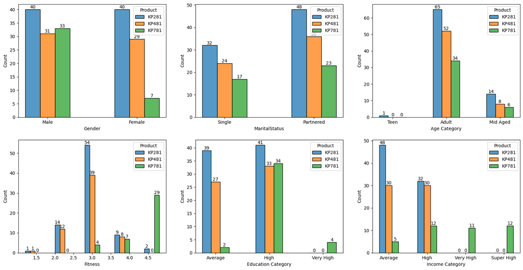

```python
def fn_bar_label(y):
    for bar in y.patches:
        # The text annotation for each bar should be its height.
        bar_value = bar.get_height()
        # Format the text with commas to separate thousands. You can do
        # any type of formatting here though.
        text = f'{bar_value:,}'
        # This will give the middle of each bar on the x-axis.
        text_x = bar.get_x() + bar.get_width() / 2
        # get_y() is where the bar starts so we add the height to it.
        text_y = bar.get_y() + bar_value
        # If we want the text to be the same color as the bar, we can
        # get the color like so:
        bar_color = bar.get_facecolor()
        # If you want a consistent color, you can just set it as a constant, e.g. #222222
        y.text(text_x, text_y, text, ha='center', va='bottom')
        #fig = plt.figure(figsize=(20,10))

fig = plt.figure(figsize=(20,10))

ax = plt.subplot(2,3,1)
y = sns.histplot(data = df, x = "Gender", shrink = 0.5, color = "Green", hue= "Product",multiple = "dodge")
#ax.legend( ncols=3)
fn_bar_label(y)

plt.subplot(2,3,2)
y = sns.histplot(data = df, x = "MaritalStatus", shrink = 0.5, color = "yellow",hue= "Product",multiple = "dodge")
fn_bar_label(y)

plt.subplot(2,3,3)
y = sns.histplot(data = df, x = "Age Category", shrink = 0.5, color = "Blue",hue= "Product",multiple = "dodge")
fn_bar_label(y)

plt.subplot(2,3,4)
y = sns.histplot(data = df, x = "Fitness", shrink = 0.5, color = "Grey",bins=5,hue= "Product",multiple = "dodge")
fn_bar_label(y)

plt.subplot(2,3,5)
y = sns.histplot(data = df, x = "Education Category", shrink = 0.5, color = "Red",bins=5,hue= "Product",multiple = "dodge")
fn_bar_label(y)

plt.subplot(2,3,6)
y = sns.histplot(data = df, x = "Income Category", shrink = 0.5, color = "Red",bins=5,hue= "Product",multiple = "dodge")
fn_bar_label(y)

plt.show()
```

#### **Product Vs Gender**

1. Male customer genrally purchase all the three products (KP281,KP481,KP781).
2. Female customer more purchasing KP281,KP481.

#### **Product Vs MaritialStatus**

3. Partnered customer purchasing KP281,KP481 more.

#### **Product Vs Age**

4. Customer age betwwen 19 and 35 purchasing significantly more then Teen,Mid-Aged and Seniors.
5. These customers are purchansing KP281,KP481 more

#### **Product Vs Fitness**

6. Customer with 3.0 fitness rating purchase KP281 more.
7. Customer with fitness 4.5 purchases KP781

#### **Product Vs Education**

8. customer with education between 14 and 17 purchase more.
9. These customers are purchansing KP281,KP481 more.
10. These customers with Education 18-19 are purchansing KP781 more.

#### **Product Vs Income**

11. Customer with salary betwween 45K- 60K purchase KP281,KP481 more.
12. Customer with salary betwween 100K and more purchase KP781 more.

# ***6. Corelation between the columns***

***Let's try to get find out wether there is any relationship between the columns***

#### ***Convert** Gender** and **MaritalStatus** into numerical values***

***Lets convert the** Gender** into a numeric values***

1 = Male

0 = Female

***Lets convert the** MaritalStatus** into a numeric values***

1 = Partnered

0 = Single

```python
def Convert_Gender(x):
    if x == "Male":
        return 1
    else:
        return 0

df["Gender_N"] = df["Gender"].apply(Convert_Gender)
df.head()
```

|  | Product | Age | Gender | Education | MaritalStatus | Usage | Fitness | Income | Miles | Age Category | Education Category | Income Category | Gender_N |
| --- | --- | --- | --- | --- | --- | --- | --- | --- | --- | --- | --- | --- | --- |
| 0 | KP281 | 18 | Male | 14 | Single | 3 | 4 | 29562 | 112 | Teen | Average | Average | 1 |
| 1 | KP281 | 19 | Male | 15 | Single | 2 | 3 | 31836 | 75 | Adult | Average | Average | 1 |
| 2 | KP281 | 19 | Female | 14 | Partnered | 4 | 3 | 30699 | 66 | Adult | Average | Average | 0 |
| 3 | KP281 | 19 | Male | 12 | Single | 3 | 3 | 32973 | 85 | Adult | Average | Average | 1 |
| 4 | KP281 | 20 | Male | 13 | Partnered | 4 | 2 | 35247 | 47 | Adult | Average | Average | 1 |

```python
def Convert_MaritalStatus(x):
    if x == "Partnered":
        return 1
    else:
        return 0

df["MaritalStatus_N"] = df["MaritalStatus"].apply(Convert_MaritalStatus)
df.head()
```

|  | Product | Age | Gender | Education | MaritalStatus | Usage | Fitness | Income | Miles | Age Category | Education Category | Income Category | Gender_N | MaritalStatus_N |
| --- | --- | --- | --- | --- | --- | --- | --- | --- | --- | --- | --- | --- | --- | --- |
| 0 | KP281 | 18 | Male | 14 | Single | 3 | 4 | 29562 | 112 | Teen | Average | Average | 1 | 0 |
| 1 | KP281 | 19 | Male | 15 | Single | 2 | 3 | 31836 | 75 | Adult | Average | Average | 1 | 0 |
| 2 | KP281 | 19 | Female | 14 | Partnered | 4 | 3 | 30699 | 66 | Adult | Average | Average | 0 | 1 |
| 3 | KP281 | 19 | Male | 12 | Single | 3 | 3 | 32973 | 85 | Adult | Average | Average | 1 | 0 |
| 4 | KP281 | 20 | Male | 13 | Partnered | 4 | 2 | 35247 | 47 | Adult | Average | Average | 1 | 1 |

```python
df_corr = df[["Age","Gender_N","Education","MaritalStatus_N","Usage","Fitness","Income","Miles"]].corr()
```

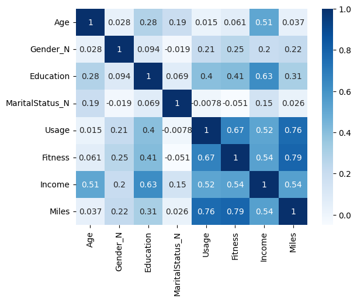

```python
sns.heatmap(data = df_corr, cmap = "Blues",annot=True)
```

##### ***Insights***

1. **Usage <-> Miles** are highly related
2. **Fitness <-> Miles** are highly related
3. **Education <-> Income** are highly related

# ***7. Probabilities***

```python
def output__marginal_probapilities(df,col):
    joint_prob_df = pd.crosstab(index = df[col],columns = df["Product"],normalize="all")
    for row_index in np.array(joint_prob_df.index):
        for col_index in np.array(joint_prob_df.columns):
            probability = round(joint_prob_df.loc[row_index,col_index] * 100,2)
            if (probability > 20):
                print(col_index, "--->", f"P({col} = {row_index}) ".ljust(35,' '), " = ", probability, "%")

column_list = ["Gender","Education Category","MaritalStatus","Fitness","Age Category","Income Category"]

for first_col in column_list:
    #print(f"Joint Probability for P[{first_col}]")
    output__marginal_probapilities(df,first_col)
    #print()
```

```
KP281 ---> P(Gender = Female)                   =  22.22 %
KP281 ---> P(Gender = Male)                     =  22.22 %
KP281 ---> P(Education Category = Average)      =  21.67 %
KP281 ---> P(Education Category = High)         =  22.78 %
KP281 ---> P(MaritalStatus = Partnered)         =  26.67 %
KP281 ---> P(Fitness = 3)                       =  30.0 %
KP481 ---> P(Fitness = 3)                       =  21.67 %
KP281 ---> P(Age Category = Adult)              =  36.11 %
KP481 ---> P(Age Category = Adult)              =  28.89 %
KP281 ---> P(Income Category = Average)         =  26.67 %
```

##### ***Insights***

1. **Adult** customers are more likely to purchase the **KP281** and **KP481**.
2. Fittness **3** customers are more likely purchase the **KP281** and **KP481**.
3. **Partnered** and **Average** income customers are more likely purshase **KP281**.

#### ***Joint Probabilities***

```python
def output_joint_probability(df,col):
    joint_prob_df = pd.crosstab(index = [df[col[0]], df[col[1]]], columns = df["Product"], normalize="all").reset_index()
    for row_index in np.array(joint_prob_df.index):
        for col_index in ["KP281","KP481","KP781"]:
            probability = round(joint_prob_df.loc[row_index,col_index] * 100,2)
            if (probability > 20):
                print(col_index, "--->", \
                      f"P({col[0]} = {joint_prob_df.loc[row_index,col[0]]} ∩ {col[1]} = {joint_prob_df.loc[row_index,col[1]]}) ".ljust(60,' '), " = ", probability, "%")

column_list = ["Gender","Education Category","MaritalStatus","Fitness","Age Category","Income Category"]

for first_col in column_list:
    for second_col in column_list:
        if (first_col != second_col):
            #print(f"Joint Probability for P[{first_col} ∩ {second_col}]")
            output_joint_probability(df,[first_col,second_col])
            #print()
```

```
KP281 ---> P(MaritalStatus = Partnered ∩ Age Category = Adult)           =  20.56 %
KP281 ---> P(Fitness = 3 ∩ Age Category = Adult)                         =  23.89 %
KP281 ---> P(Age Category = Adult ∩ MaritalStatus = Partnered)           =  20.56 %
KP281 ---> P(Age Category = Adult ∩ Fitness = 3)                         =  23.89 %
KP281 ---> P(Age Category = Adult ∩ Income Category = Average)           =  24.44 %
KP281 ---> P(Income Category = Average ∩ Age Category = Adult)           =  24.44 %
```

#### ***Conditional Probabilities***

```python
def output_cond_probability(df,col):
    joint_prob_df = pd.crosstab(index = df[col],columns = df["Product"],normalize="index")
    for row_index in np.array(joint_prob_df.index):
        for col_index in np.array(joint_prob_df.columns):
            probability = round(joint_prob_df.loc[row_index,col_index] * 100,2)
            if (probability >= 50):
                print(f"P({col_index} | {row_index}) ".ljust(35,' '), " = ", probability, "%")

column_list = ["Gender","Education Category","MaritalStatus","Fitness","Age Category","Income Category"]

for first_col in column_list:
    print(f"Conditional Probability for {first_col}")
    output_cond_probability(df,first_col)
    print()
```

```
Conditional Probability for Gender
P(KP281 | Female)                    =  52.63 %

Conditional Probability for Education Category
P(KP281 | Average)                   =  57.35 %
P(KP781 | Very High)                 =  100.0 %

Conditional Probability for MaritalStatus

Conditional Probability for Fitness
P(KP281 | 1)                         =  50.0 %
P(KP481 | 1)                         =  50.0 %
P(KP281 | 2)                         =  53.85 %
P(KP281 | 3)                         =  55.67 %
P(KP781 | 5)                         =  93.55 %

Conditional Probability for Age Category
P(KP281 | Teen)                      =  100.0 %
P(KP281 | Mid Aged)                  =  50.0 %

Conditional Probability for Income Category
P(KP281 | Average)                   =  57.83 %
P(KP781 | Very High)                 =  100.0 %
P(KP781 | Super High)                =  100.0 %
```